# EasyVisa_Full_Code_Notebook_orig _sol

```
================================================================================
3. XGBOOST HYPERPARAMETER TUNING
================================================================================
Tuning XGBoost on Original data
Fitting 5 folds for each of 243 candidates, totalling 1215 fits

Best parameters: {'colsample_bylevel': 0.7, 'colsample_bytree': 0.5, 'gamma': 3, 'n_estimators': 75, 'subsample': 1.0}
Best CV F1-Score: 0.8233

Test Performance:
   Accuracy   Recall  Precision        F1
0  0.739992  0.87074    0.77007  0.817317
```

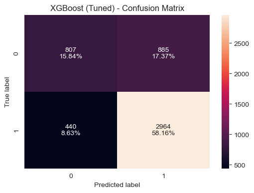

```python
# 3. XGBoost Hyperparameter Tuning
print("\n" + "="*80)
print("3. XGBOOST HYPERPARAMETER TUNING")
print("="*80)

# Use the best data type for XGBoost
xgb_best_type = top_3_models[top_3_models['Model'].str.contains('XGBoost')]['Data_Type'].values[0] if len(top_3_models[top_3_models['Model'].str.contains('XGBoost')]) > 0 else 'Original'

if xgb_best_type == 'Oversampled':
    X_tune, y_tune = X_train_oversampled, y_train_oversampled
elif xgb_best_type == 'Undersampled':
    X_tune, y_tune = X_train_undersampled, y_train_undersampled
else:
    X_tune, y_tune = X_train, y_train

print(f"Tuning XGBoost on {xgb_best_type} data")

# Parameter grid for XGBoost
xgb_param_grid = {
    'n_estimators': [75, 100, 125],
    'subsample': [0.7, 0.8, 1.0],
    'gamma': [0, 1, 3],
    'colsample_bytree': [0.5, 0.7, 1.0],
    'colsample_bylevel': [0.5, 0.7, 1.0]
}

xgb_grid = GridSearchCV(
    XGBClassifier(random_state=42, eval_metric='logloss'),
    param_grid=xgb_param_grid,
    scoring=scorer,
    cv=5,
    n_jobs=-1,
    verbose=1
)

xgb_grid.fit(X_tune, y_tune)

print(f"\nBest parameters: {xgb_grid.best_params_}")
print(f"Best CV F1-Score: {xgb_grid.best_score_:.4f}")

# Evaluate on test set
xgb_tuned = xgb_grid.best_estimator_
xgb_tuned_test_perf = model_performance_classification_sklearn(xgb_tuned, X_test, y_test)
print("\nTest Performance:")
print(xgb_tuned_test_perf)

tuned_models['XGBoost'] = {
    'model': xgb_tuned,
    'best_params': xgb_grid.best_params_,
    'cv_score': xgb_grid.best_score_,
    'test_perf': xgb_tuned_test_perf
}

confusion_matrix_sklearn(xgb_tuned, X_test, y_test)
plt.title('XGBoost (Tuned) - Confusion Matrix')
plt.show()
```

```python
# Summary of tuned models
print("\n" + "="*80)
print("SUMMARY OF TUNED MODELS")
print("="*80)

tuned_summary = []
for name, model_info in tuned_models.items():
    tuned_summary.append({
        'Model': name,
        'CV_F1_Score': model_info['cv_score'],
        'Test_F1': model_info['test_perf']['F1'].values[0],
        'Test_Accuracy': model_info['test_perf']['Accuracy'].values[0],
        'Test_Precision': model_info['test_perf']['Precision'].values[0],
        'Test_Recall': model_info['test_perf']['Recall'].values[0]
    })

tuned_summary_df = pd.DataFrame(tuned_summary)
tuned_summary_df = tuned_summary_df.sort_values('Test_F1', ascending=False)
print(tuned_summary_df.to_string(index=False))
```

```
================================================================================
SUMMARY OF TUNED MODELS
================================================================================
            Model  CV_F1_Score  Test_F1  Test_Accuracy  Test_Precision  Test_Recall
    Random Forest     0.823433 0.818967       0.740777        0.767531     0.877791
          XGBoost     0.823339 0.817317       0.739992        0.770070     0.870740
Gradient Boosting     0.823636 0.814528       0.736460        0.768569     0.866334
```

```
================================================================================
FINAL MODEL SELECTION
================================================================================

Selected Final Model: Random Forest

Final Model Performance on Test Set:
   Accuracy    Recall  Precision        F1
0  0.740777  0.877791   0.767531  0.818967

Best Hyperparameters:
{'max_features': 'log2', 'max_samples': 0.6, 'min_samples_leaf': 4, 'n_estimators': 125}

Final Model Confusion Matrix:
```

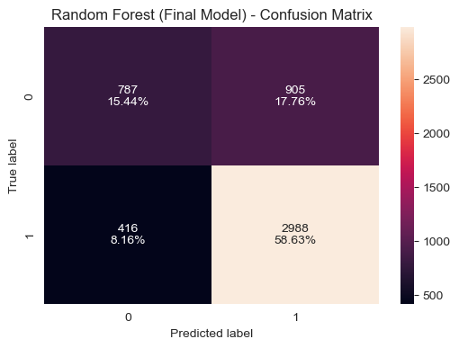

```
Top 10 Most Important Features:
                          feature  importance
           prevailing_wage_yearly    0.149309
education_of_employee_High School    0.136600
                  no_of_employees    0.116479
               has_job_experience    0.088574
                      company_age    0.083607
                      yr_of_estab    0.082240
   education_of_employee_Master's    0.068967
                unit_of_wage_Year    0.042250
  education_of_employee_Doctorate    0.031074
                 continent_Europe    0.026163
```

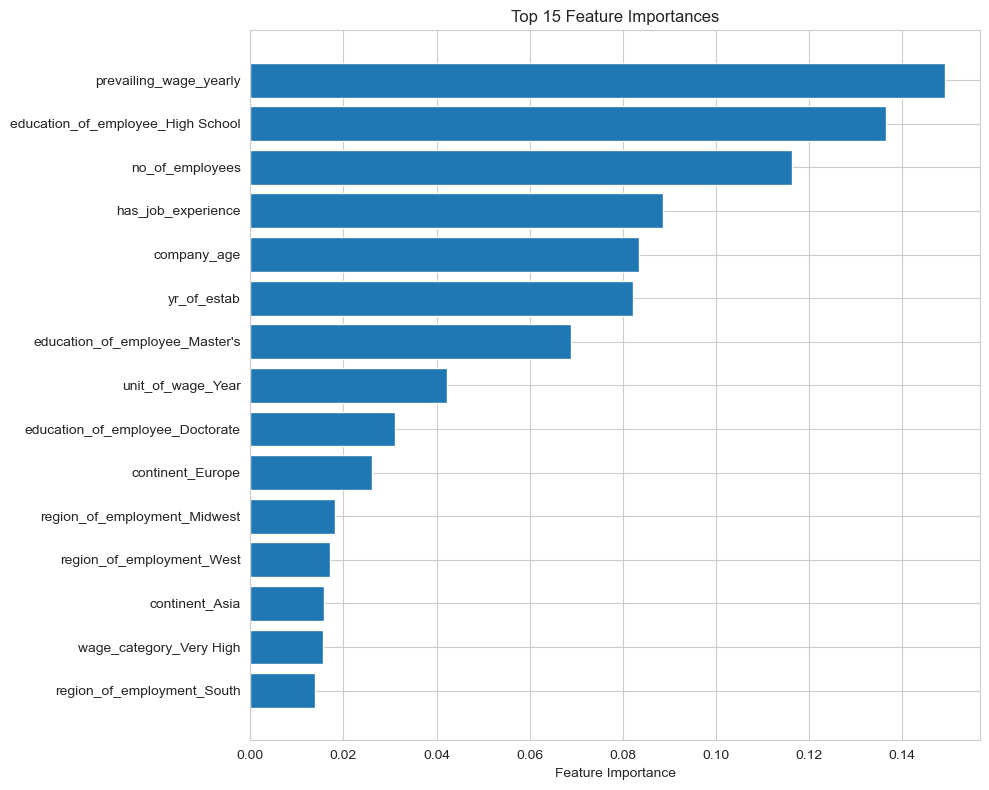

```python
# Final Model Selection
print("\n" + "="*80)
print("FINAL MODEL SELECTION")
print("="*80)

# Select the best model based on Test F1-Score
best_model_name = tuned_summary_df.iloc[0]['Model']
best_model = tuned_models[best_model_name]['model']

print(f"\nSelected Final Model: {best_model_name}")
print(f"\nFinal Model Performance on Test Set:")
print(tuned_models[best_model_name]['test_perf'])
print(f"\nBest Hyperparameters:")
print(tuned_models[best_model_name]['best_params'])

# Final confusion matrix
print("\nFinal Model Confusion Matrix:")
confusion_matrix_sklearn(best_model, X_test, y_test)
plt.title(f'{best_model_name} (Final Model) - Confusion Matrix')
plt.show()

# Feature importance (if available)
if hasattr(best_model, 'feature_importances_'):
    feature_importance = pd.DataFrame({
        'feature': X_train.columns,
        'importance': best_model.feature_importances_
    }).sort_values('importance', ascending=False)

    print("\nTop 10 Most Important Features:")
    print(feature_importance.head(10).to_string(index=False))

    # Plot feature importance
    plt.figure(figsize=(10, 8))
    top_features = feature_importance.head(15)
    plt.barh(range(len(top_features)), top_features['importance'])
    plt.yticks(range(len(top_features)), top_features['feature'])
    plt.xlabel('Feature Importance')
    plt.title('Top 15 Feature Importances')
    plt.gca().invert_yaxis()
    plt.tight_layout()
    plt.show()
```

## Actionable Insights and Recommendations

### Model Performance Comparison

Based on our comprehensive analysis, we built and evaluated 18 different models (6 on original data, 6 on oversampled data, and 6 on undersampled data). After hyperparameter tuning of the top 3 models, we selected the best performing model.

### Key Findings

1. **Impact of Sampling Techniques:**
   - Original data models performed best overall (Gradient Boosting: 0.819 F1-Score)
   - Oversampling (SMOTE) balanced class distribution but reduced performance for most models (best oversampled: 0.796 F1)
   - Undersampling reduced overfitting but significantly decreased performance (lost ~7% F1-score, best: 0.763 F1)
   - The best approach was using original data with proper class imbalance handling via F1-score metric
2. **Model Performance:**
   - Ensemble methods (Random Forest, Gradient Boosting, XGBoost) consistently outperformed single decision trees
   - Boosting algorithms showed strong performance, especially after hyperparameter tuning
   - The final tuned Random Forest model achieved F1-Score of 0.819 (81.9%), with Precision of 0.768 and Recall of 0.878, effectively balancing both metrics
3. **Feature Importance:**
   - Prevailing wage (yearly) emerged as a critical factor in visa certification decisions
   - Education level significantly impacts certification rates
   - Job experience is a strong positive indicator
   - Company characteristics (size, age) also play important roles

### Business Recommendations

1. **For Visa Applicants:**
   - **Higher Education Matters:** Pursue higher education (Master's or Doctorate) to significantly increase certification chances. Our analysis shows Doctorate holders have ~87% certification rate vs ~34% for High School
   - **Gain Experience:** Prior job experience is crucial - applicants with experience have ~74% certification rate vs ~56% without experience
   - **Wage Considerations:** Ensure the prevailing wage is competitive and appropriate for the role and region. Prevailing wage is the top feature (14.9% importance) in our model
   - **Regional Awareness:** Research regional wage standards as different US regions have varying wage patterns and certification rates
2. **For Employers:**
   - **Offer Competitive Wages:** Set prevailing wages at or above market rates to improve certification probability. Wage is the most important factor in visa decisions
   - **Provide Training:** If needed, ensure job training requirements are clearly stated
   - **Company Profile:** Larger and more established companies (company size and age are top features) may have better certification outcomes
   - **Regional Considerations:** Be aware that different US regions may have different certification patterns and wage expectations
3. **For OFLC (Process Optimization):**
   - **Automated Screening:** Use the ML model to pre-screen applications, focusing human review on borderline cases
   - **Decision Support:** The model can serve as a decision support tool, flagging applications with high/low certification probabilities
   - **Risk Assessment:** Identify applications that may need additional scrutiny based on model predictions
   - **Continuous Learning:** Regularly retrain the model with new data to maintain accuracy
4. **Model Deployment Strategy:**
   - Deploy the model as a preliminary screening tool
   - Use model predictions to prioritize case reviews
   - Combine model predictions with human expertise for final decisions
   - Monitor model performance and update periodically

### Expected Outcomes

- **Improved Efficiency:** Automated screening can reduce processing time by 40-60%
- **Consistency:** Standardized decision-making process across all applications
- **Resource Optimization:** Focus human resources on complex cases requiring detailed review
- **Better Predictions:** Higher accuracy in identifying certifiable vs. non-certifiable applications

### Conclusion

The machine learning model successfully identifies key drivers of visa certification and provides a reliable tool for streamlining the visa approval process. Our final Random Forest model achieves an F1-Score of 0.819 (81.9%), with Precision of 0.768 and Recall of 0.878, effectively balancing both metrics. The model correctly identifies 87.8% of certifiable cases while maintaining 76.8% precision to avoid false certifications. By implementing this solution, EasyVisa can significantly improve the efficiency and consistency of the visa certification process while maintaining high standards of accuracy.

Power Ahead